# Initial data exploration: Regulation of temperature via depth in response to seasonal changes in SST in *Carcharhinus amblyrhynchos*

### Effect of SST on sharks - maximum daily temperatures

Temperature is well known to have an effect on shark movement and ecology in general (Schlaff et al 2014 and refs therein). *C. amblyrhyncos* are known to remain resident at Osprey reef (Barnett et al 2012), so the most likely movements will be depth. Temperature readings from sharks occupying surface waters should correspond to SSTs from satellite data:

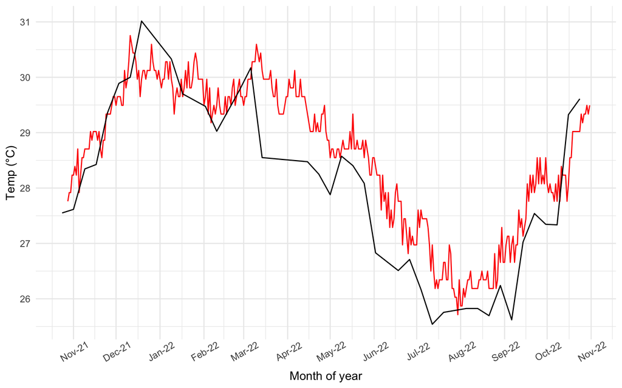

Red line = daily max temps recorded by sharks in our study, black line = SSTs from the 11micron daytime MODISA satellite data. On the whole they track together pretty well, but looks like the sharks are running a little hot compared to our remote-sensed SST data.

### Mean daily temperatures

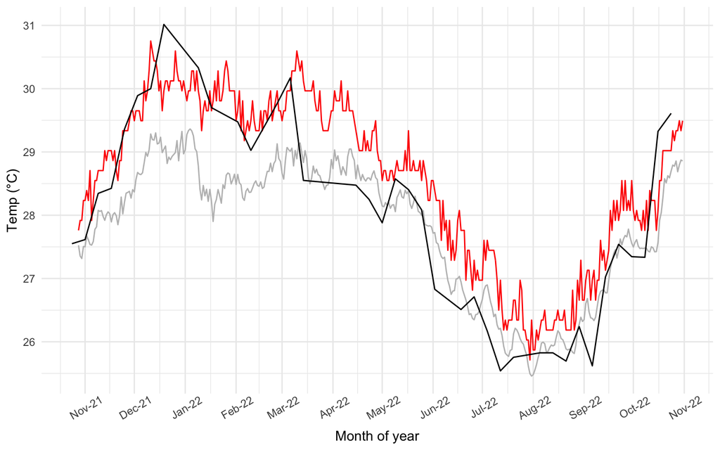

Red line = daily max temps recorded by sharks in our study, grey line = daily mean temps, black line = SSTs from the 11micron daytime MODISA satellite data. It looks like our sharks are able to down-regulate their mean daily temperatures, particularly in the summer.

### Minimum daily temperatures

Presumably if mean temperatures are lower than max temperatures, there must be some regular forays into colder water to achieve this.

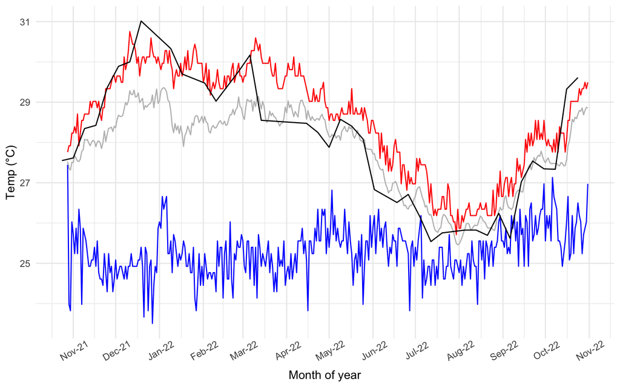

Red line = daily max temps recorded by sharks in our study, grey line = daily mean temps, blue line = daily min temps, black line = SSTs from the 11micron daytime MODISA satellite data. It does indeed appear that our sharks are accessing colder waters during the summer period. This is presumably a result of accessing deeper waters. Will check against depth movements to find out.

### Maximum, mean and minimum daily depths

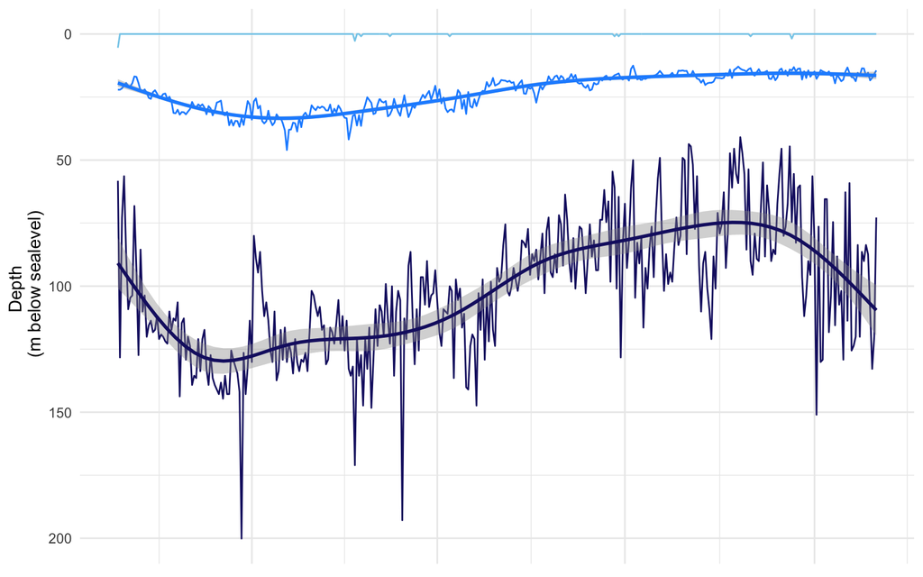

So, as predicted from the max temperatures, daily minimum depths are around 0m (light blue line), which means these animals make regular movements into surface waters (feeding?). Mean depths appear to be somewhat deeper in the summer and maximum daily depths are a lot deeper. By how much? Need to model this with a GAM to assess properly but it looks like winter max depths are on average around 75m, while summer max depths are around 125m:

### Summer vs winter max depth comparison

```r
shark_daily_depths %>%
  mutate(month = month(date, label = TRUE)) %>%
  group_by(month) %>%
  summarise(mean_daily_max_depth = mean(daily_max_depth))
```

| month | mean_daily_max_depth |
| --- | --- |
| Jan | 117.93820 |
| Feb | 124.79135 |
| Mar | 111.89310 |
| Apr | 114.83446 |
| May | 89.41471 |
| Jun | 83.20723 |
| Jul | 81.55020 |
| Aug | 73.36290 |
| Sep | 75.99027 |
| Oct | 98.45553 |

[output cut: 2 more lines]

So maximum summer depths accessed around around 125m, compared to winter where maximum depths were around 75m. Given that the GBR shelf sits at around ~50m, it makes you wonder what these species do to cool down in the summer there? Perhaps there is more latitudinal movement in coastal individuals/populations?

### Summary and next steps

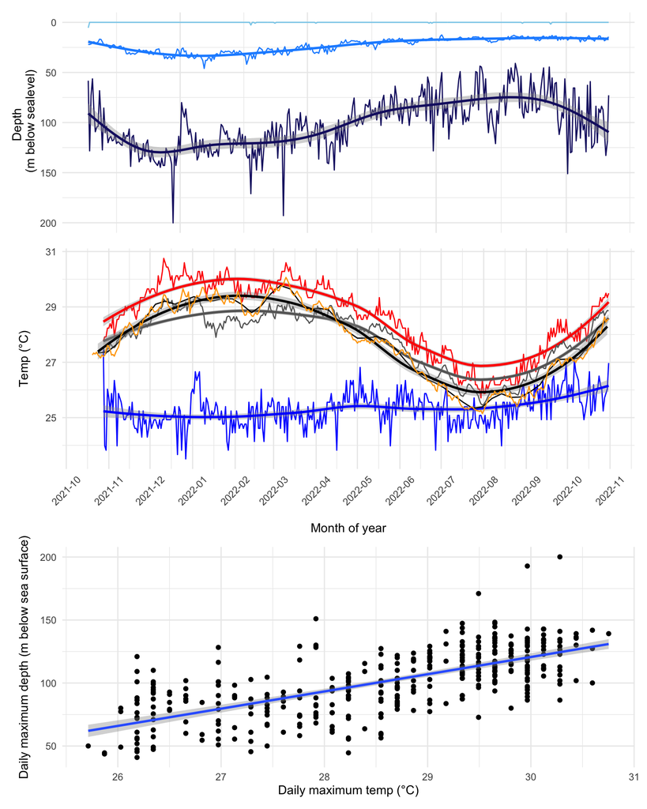

The top plot above shows the combined daily minimum, mean and maximum depths and temps respectively, along with a simple GAM smoother - I am yet to model this properly, but will do as a next step. The figure below that shows the overall relationship between daily max temps and depths - the hotter their daily maximum temp is, the deeper the overall daily depth is. I will run a generalised linear (mixed effect - with individual as the random effect) model on this to quantify.

Proposed next analysis/steps:

- Properly model variations in SST vs Depth over time using GAM
- Quantify overall relationship between SSTs and max depths via GLMM
- Investigate if there is a story in individual movements - do downward movements in summer happen at regular time intervals? How long do individuals spend at depth? At this scale there are only 15 individuals so the data may get quite thin. Will see if I can tease this out.

##### Summary thoughts so far:

There definitely seems to be a story in here and I am keen to include this in my thesis. I think it fits with the story of how isolated pinnacle/seamount type habitats might actually confer some advantages to coral reef predators, that mitigate their isolation, especially in the context of warming oceans.